# Data Analysis Project Final Report

### Results

```r
options(scipen=999)
model_data = data.frame(row_labels=c("Forward Search 1", "Backward Search 1", "Backward Search 2", "Backward Search 3*", "Manual Selection 4", "Forward Search 2", "Forward Search 3", "Backward Search 4*", "Manual Selection 1", "Manual Selection 2", "Manual Selection 3"),
loocv_RMSE = c(fw1_loocv, bw1_loocv, bw2_loocv, bw3_loocv, man4_loocv, fw2_loocv, fw3_loocv, bw4_loocv, man1_loocv, man2_loocv, man3_loocv))
library(knitr)
kable(model_data, format = "markdown", col.names = c("Models", "Train LOOCV RMSE"))
```

| Models | Train LOOCV RMSE |
| --- | --- |
| Forward Search 1 | 358807.3567130 |
| Backward Search 1 | 358807.3567130 |
| Backward Search 2 | 324892.8041520 |
| Backward Search 3* | 309200.5151790 |
| Manual Selection 4 | 367601.6762770 |
| Forward Search 2 | 0.2617049 |
| Forward Search 3 | 0.2434668 |
| Backward Search 4* | 0.2172096 |
| Manual Selection 1 | 0.2486561 |
| Manual Selection 2 | 0.2340481 |
| Manual Selection 3 | 0.3442453 |

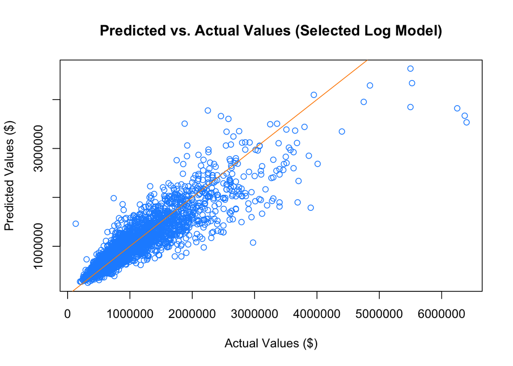

```r
# plot actual vs. predicted price values with the selected model
plot(pred_vals ~ housing_trn$Price, xlab = "Actual Values ($)", ylab = "Predicted Values ($)", main = "Predicted vs. Actual Values (Selected Log Model)", col = "dodgerblue", cex = 1)
abline(0,1, col="darkorange", lwd = 1) # perfect response matches will be on this line
```

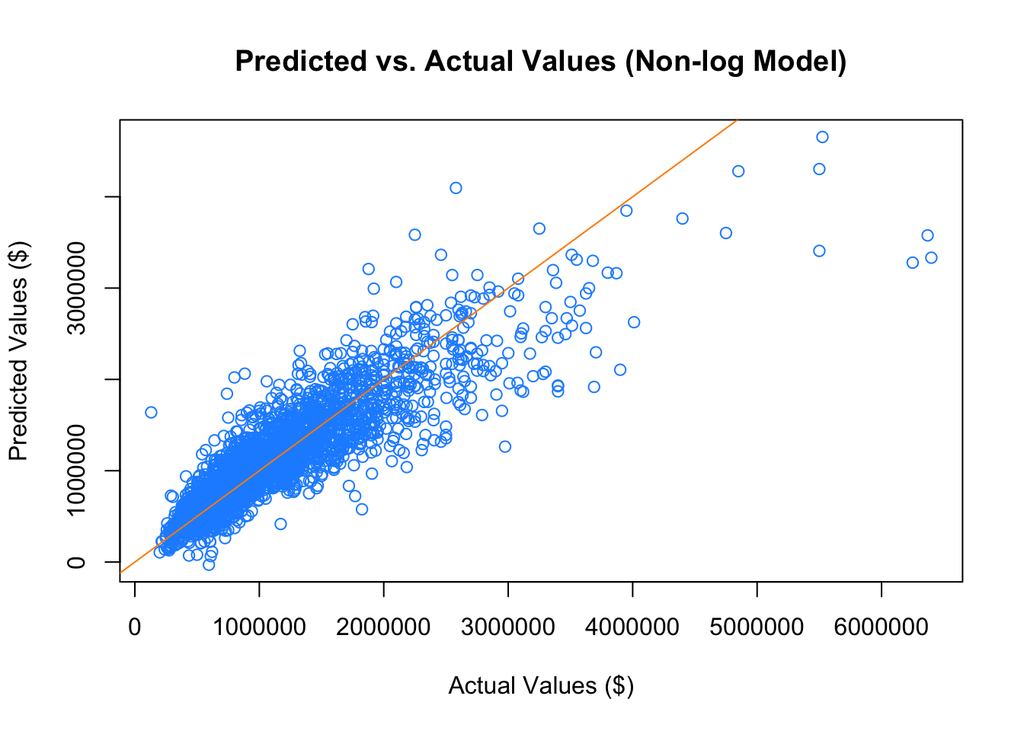

```r
# plot actual vs. predicted price values with the non-log alternate model
plot(pred_vals2 ~ housing_trn$Price, xlab = "Actual Values ($)", ylab = "Predicted Values ($)", main = "Predicted vs. Actual Values (Non-log Model)", col = "dodgerblue", cex = 1)
abline(0,1, col="darkorange", lwd = 1) # perfect response matches will be on this line
```

- Here we see the two Actual vs. Predicted price plots of the final two models in contention. While both plots seem to follow the general trend of the training data, we see more overestimates at the low end of the price spectrum, which is where we believe the model should be most accurate. In addition, we should bring up the one negative price prediction the non-log model produced (seen in the `Methods` section). As a price should never be negative (unless somehow you paid someone to take a property off your hands…), this hints at a flaw in the non-log response model. Thus we can be more confident in the log-response model as we do not see any negative prices (nor would be expect any). The final training RMSE of the selected model is 290469.4374888.

```r
# This analysis is secondary to the goal of prediciting housing values (vs. explaining), but still worthy of investigating in case we did want to use the model for explanation

# check the final two selected models (one log-response, other non-log)
library(lmtest)
```

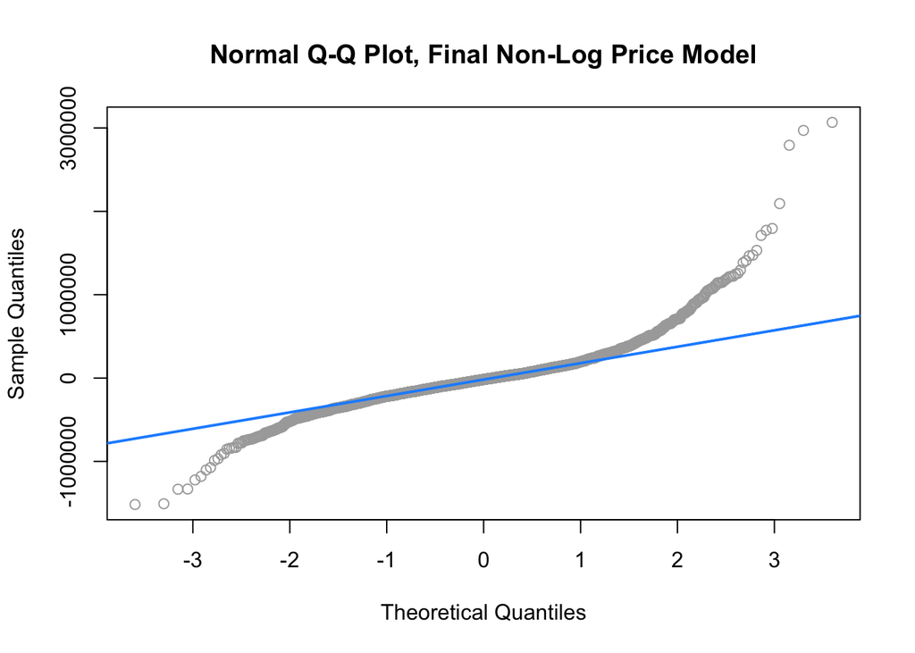

```r
qqnorm(resid(final_nonlog_model), main = "Normal Q-Q Plot, Final Non-Log Price Model", col = "darkgrey")
qqline(resid(final_nonlog_model), col = "dodgerblue", lwd = 2)
```

```r
shapiro.test(resid(final_nonlog_model))
```

```
##
##  Shapiro-Wilk normality test
##
## data:  resid(final_nonlog_model)
## W = 0.87301, p-value < 0.00000000000000022
```

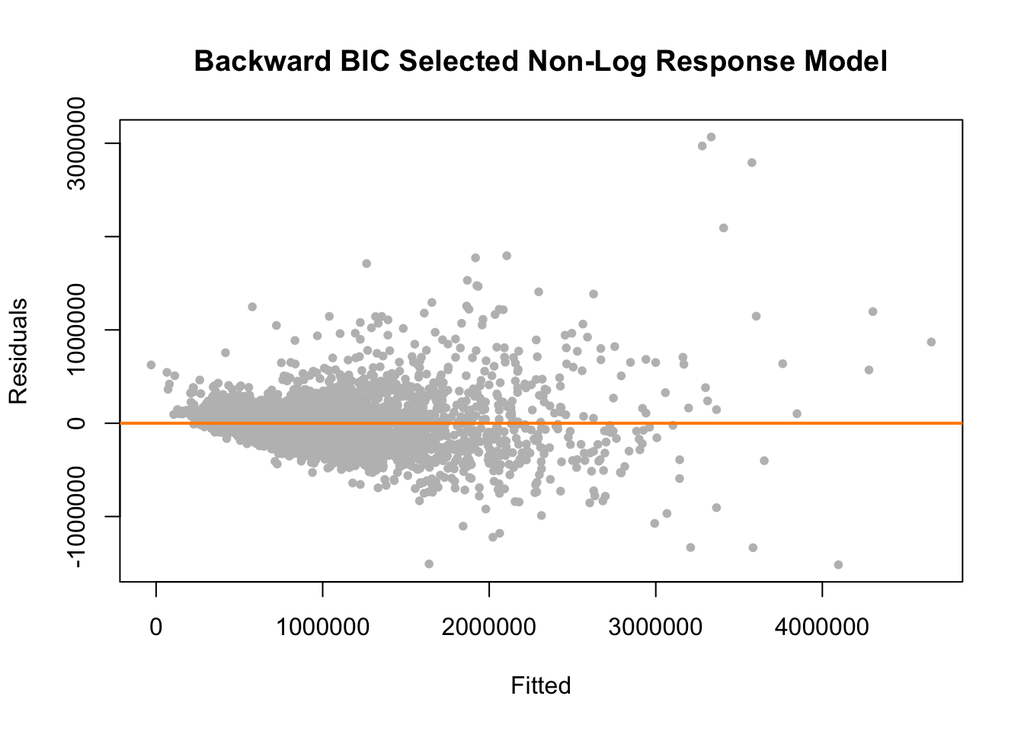

```r
plot(fitted(final_nonlog_model), resid(final_nonlog_model), col = "grey", pch = 20, xlab = "Fitted", ylab = "Residuals", main = "Backward BIC Selected Non-Log Response Model")
abline(h = 0, col = "darkorange", lwd = 2)
```

```r
bptest(final_nonlog_model)
```

```
##
##  studentized Breusch-Pagan test
##
## data:  final_nonlog_model
## BP = 495.94, df = 53, p-value < 0.00000000000000022
```

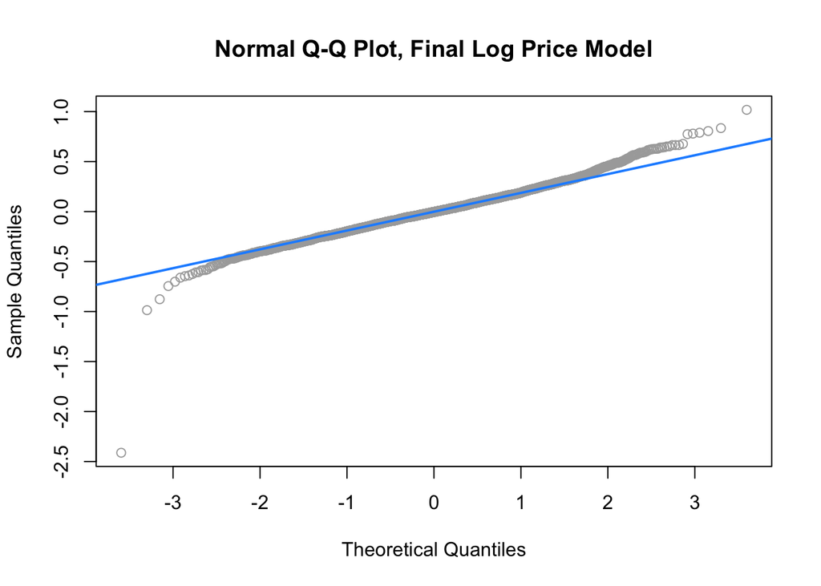

```r
qqnorm(resid(final_log_model), main = "Normal Q-Q Plot, Final Log Price Model", col = "darkgrey")
qqline(resid(final_log_model), col = "dodgerblue", lwd = 2)
```

```r
shapiro.test(resid(final_log_model))
```

```
##
##  Shapiro-Wilk normality test
##
## data:  resid(final_log_model)
## W = 0.97305, p-value < 0.00000000000000022
```

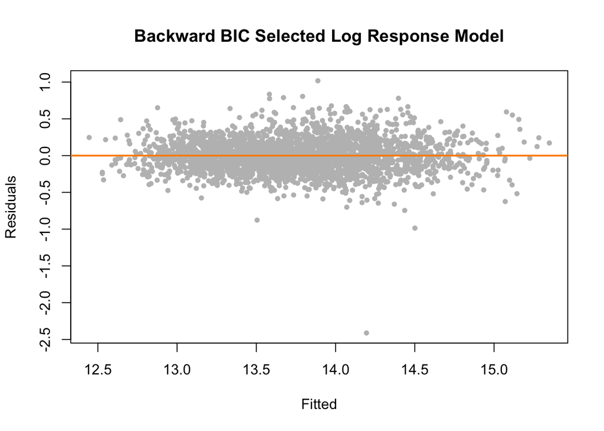

```r
plot(fitted(final_log_model), resid(final_log_model), col = "grey", pch = 20, xlab = "Fitted", ylab = "Residuals", main = "Backward BIC Selected Log Response Model")
abline(h = 0, col = "darkorange", lwd = 2)
```

```r
bptest(final_log_model)
```

```
##
##  studentized Breusch-Pagan test
##
## data:  final_log_model
## BP = 122.85, df = 59, p-value = 0.000002181
```

- We can see that the log-response model has a much better looking Normal Q-Q plot and Fitted vs. Residuals plot (though both still fail the Shapiro and Breusch-Pagan tests….which is ok if we are just using the model for prediction). This gives us even more confidence that the log model was the correct choice between the final two for prediction of housing prices, but it would be quite difficult (if not flawed) to use this model for explanation of relationships between predictors and the price response.

```r
# Training results table
model_data2 = data.frame(row_labels=c("Final model", "Runner-up"),
final_RMSE = c(final_model_RMSE, nonlog_model_RMSE),
final_avg_pct_error = c(avg_pct_error1, avg_pct_error2))
kable(model_data2, format = "markdown", col.names = c("Models", "Training RMSE", "Avg % Error"))
```

| Models | Training RMSE | Avg % Error |
| --- | --- | --- |
| Final model | 290469.4 | 16.40307 |
| Runner-up | 300455.9 | 19.28500 |

```r
# Performance of the log model on the test data
pred_vals_final = exp(predict(final_log_model, newdata = housing_tst))
final_data_test_RMSE = sqrt(mean((pred_vals_final - housing_tst$Price)^2))
(avg_pct_error_final = mean(abs((pred_vals_final - housing_tst$Price))/housing_tst$Price) * 100)
```

```
## [1] 17.06583
```

```r
# Final results table
model_data3 = data.frame(row_labels=c("Final model"),
final_RMSE = c(final_data_test_RMSE),
final_avg_pct_error = c(avg_pct_error_final))
kable(model_data3, format = "markdown", col.names = c("Model", "Test RMSE", "Avg % Error"))
```

| Model | Test RMSE | Avg % Error |
| --- | --- | --- |
| Final model | 318041.9 | 17.06583 |

- As it is frowned upon to compare models (and make a selection between two) based on the test set, we decided to use the training data and select the model with the lowest regular RMSE (which also happened to have the lowest average percent error) to be our final model. The table above displays the final results of our selected model on the test set.

### Discussion

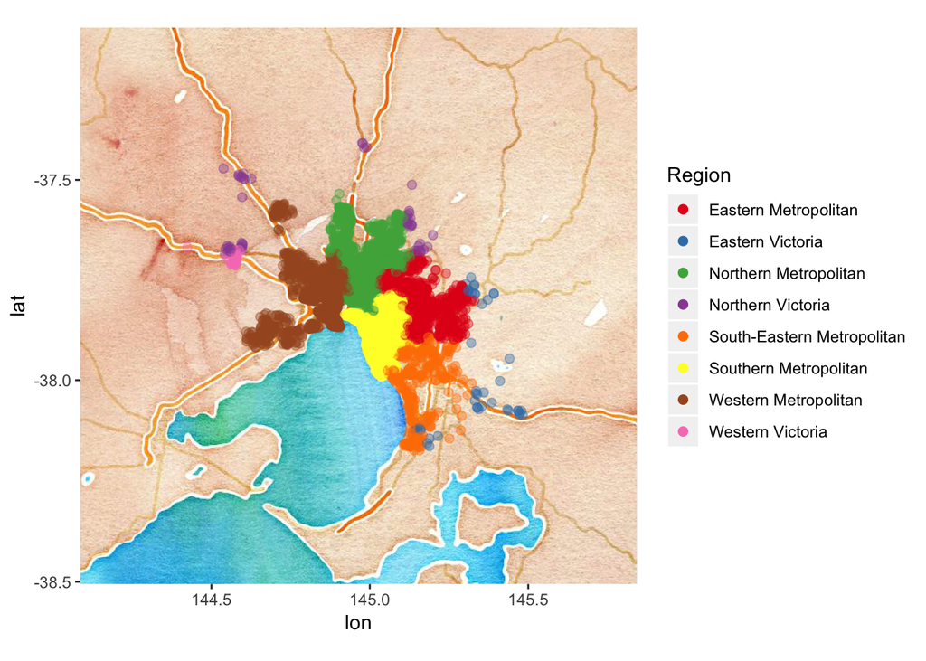

```r
library(ggplot2)
library(ggmap)

# original data set
 melbourn_housing = read_csv("Melbourne_housing_FULL.csv", na = "NA")
 melbourn_housing = na.omit(melbourn_housing)
 melbourn_housing$Regionname = as.factor(melbourn_housing$Regionname)

# set color scale
library(RColorBrewer)
myColors = brewer.pal(8,"Set1")
names(myColors) = levels(melbourn_housing$Regionname)
colScale = scale_colour_manual(name = "Region",values = myColors)

melbourn_map = get_map(location = "melbourne", maptype = "watercolor", zoom = 9)
ggmap(melbourn_map) + geom_point(
  aes(x = Longtitude, y = Lattitude, colour = Regionname),
  alpha = 0.4,
  size = 2,
  data = melbourn_housing
  ) + colScale + guides(colour = guide_legend(override.aes = list(alpha = 1)))
```

- In regards to generalizing this model to other markets, `Regionname` would probably have to be recreated, and may end up behaving differently depending how the area splits up their regions. Measurement units would also need to be standardized if a US market was used, as SI units were used in this dataset. Above the latitude and longitude of all of the properties from the data set are plotted on top of a map of Melbourne - not every city would be able to be broken up as such (especially being a port next to the ocean), so this model may not generalize very well, but the methods could be followed for any similar datasets.

### Appendix

```r
# Summary output of all models compared before final selection:
summary(forward_bic_model_1)
```

```
##
## Call:
## lm(formula = Price ~ BuildingArea + CouncilArea + Type + Distance +
##     Rooms + YearBuilt + Bathroom + Car + Method + Landsize, data = housing_trn)
##
## Residuals:
##      Min       1Q   Median       3Q      Max
## -1719891  -186628   -28503   146390  3929894
##
## Coefficients:
##                                              Estimate  Std. Error t value
## (Intercept)                               5980620.304  460923.648  12.975
## BuildingArea                                 2541.764     129.413  19.641
## CouncilAreaBayside City Council            581731.923   45624.038  12.751
## CouncilAreaBoroondara City Council         607871.258   38155.816  15.931
## CouncilAreaBrimbank City Council          -246986.371   41553.839  -5.944
## CouncilAreaCardinia Shire Council          130866.439  195821.696   0.668
## CouncilAreaCasey City Council              272371.640  110185.510   2.472
## CouncilAreaDarebin City Council             32965.591   37491.779   0.879
## CouncilAreaFrankston City Council          430284.076   93026.402   4.625
## CouncilAreaGlen Eira City Council          282863.147   40015.616   7.069
## CouncilAreaGreater Dandenong City Council  195806.508   97621.504   2.006
## CouncilAreaHobsons Bay City Council         40970.075   48100.177   0.852
## CouncilAreaHume City Council              -147513.022   46448.643  -3.176
## CouncilAreaKingston City Council           271858.064   55840.782   4.868
## CouncilAreaKnox City Council                84841.664   68190.909   1.244
## CouncilAreaMacedon Ranges Shire Council    437039.733  203943.236   2.143
## CouncilAreaManningham City Council         182800.549   47107.407   3.881
## CouncilAreaMaribyrnong City Council       -126746.925   42268.313  -2.999
## CouncilAreaMaroondah City Council          163662.704   66676.262   2.455
## CouncilAreaMelbourne City Council          210202.411   45884.524   4.581
## CouncilAreaMelton City Council            -127735.804   72349.516  -1.766
## CouncilAreaMitchell Shire Council          492803.225  264245.643   1.865
## CouncilAreaMonash City Council             252972.910   45467.616   5.564
## CouncilAreaMoonee Valley City Council       63069.467   40331.807   1.564
## CouncilAreaMoreland City Council           -41100.084   38677.916  -1.063
## CouncilAreaNillumbik Shire Council         -17565.495  106718.460  -0.165
## CouncilAreaPort Phillip City Council       489958.688   48809.272  10.038
## CouncilAreaStonnington City Council        616537.834   47183.484  13.067
## CouncilAreaWhitehorse City Council         284384.645   63273.013   4.495
```

[output cut: 53 more lines]

```
## Rooms                                         0.00000000464110 ***
## YearBuilt                                 < 0.0000000000000002 ***
## Bathroom                                  < 0.0000000000000002 ***
## Car                                           0.00000003002610 ***
## MethodS                                       0.00000000026414 ***
## MethodSA                                              0.983598
## MethodSP                                      0.00004519659281 ***
## MethodVB                                              0.263873
## Landsize                                              0.000296 ***
## ---
## Signif. codes:  0 '***' 0.001 '**' 0.01 '*' 0.05 '.' 0.1 ' ' 1
##
## Residual standard error: 355500 on 3056 degrees of freedom
## Multiple R-squared:  0.7017, Adjusted R-squared:  0.6974
## F-statistic: 163.3 on 44 and 3056 DF,  p-value: < 0.00000000000000022
```

```r
summary(forward_bic_model_2)
```

```
##
## Call:
## lm(formula = log(Price) ~ BuildingArea + YearBuilt + Regionname +
##     Type + Distance + Rooms + Bathroom + Method + Landsize +
##     Car, data = housing_trn)
##
## Residuals:
##      Min       1Q   Median       3Q      Max
## -2.41605 -0.16341  0.00101  0.15810  1.09658
##
## Coefficients:
##                                          Estimate   Std. Error t value
## (Intercept)                          18.903355359  0.325452869  58.083
## BuildingArea                          0.001780839  0.000093619  19.022
## YearBuilt                            -0.002756074  0.000169637 -16.247
## RegionnameEastern Victoria            0.196654047  0.066284842   2.967
## RegionnameNorthern Metropolitan      -0.259474614  0.017313191 -14.987
## RegionnameNorthern Victoria           0.006955378  0.057763733   0.120
## RegionnameSouth-Eastern Metropolitan  0.167139262  0.028961251   5.771
## RegionnameSouthern Metropolitan       0.101902854  0.017316305   5.885
## RegionnameWestern Metropolitan       -0.316749815  0.017500792 -18.099
## RegionnameWestern Victoria           -0.297873920  0.064843079  -4.594
## Typet                                -0.101274477  0.019571099  -5.175
## Typeu                                -0.470527907  0.017333946 -27.145
## Distance                             -0.035189717  0.001061408 -33.154
## Rooms                                 0.084993952  0.008353761  10.174
## Bathroom                              0.103561229  0.009697221  10.679
## MethodS                               0.118089941  0.014673864   8.048
## MethodSA                              0.012075515  0.062891229   0.192
## MethodSP                              0.094683787  0.018442406   5.134
## MethodVB                              0.036267898  0.020701062   1.752
## Landsize                              0.000039629  0.000006733   5.886
## Car                                   0.029626856  0.006048911   4.898
##                                                  Pr(>|t|)
## (Intercept)                          < 0.0000000000000002 ***
## BuildingArea                         < 0.0000000000000002 ***
## YearBuilt                            < 0.0000000000000002 ***
## RegionnameEastern Victoria                        0.00303 **
## RegionnameNorthern Metropolitan      < 0.0000000000000002 ***
## RegionnameNorthern Victoria                       0.90417
## RegionnameSouth-Eastern Metropolitan  0.00000000865616474 ***
## RegionnameSouthern Metropolitan       0.00000000441417315 ***
## RegionnameWestern Metropolitan       < 0.0000000000000002 ***
## RegionnameWestern Victoria            0.00000452783518025 ***
## Typet                                 0.00000024291664565 ***
## Typeu                                < 0.0000000000000002 ***
## Distance                             < 0.0000000000000002 ***
## Rooms                                < 0.0000000000000002 ***
## Bathroom                             < 0.0000000000000002 ***
## MethodS                               0.00000000000000119 ***
## MethodSA                                          0.84775
## MethodSP                              0.00000030122841558 ***
## MethodVB                                          0.07988 .
## Landsize                              0.00000000437962918 ***
## Car                                   0.00000101871228416 ***
## ---
## Signif. codes:  0 '***' 0.001 '**' 0.01 '*' 0.05 '.' 0.1 ' ' 1
##
## Residual standard error: 0.2603 on 3080 degrees of freedom
## Multiple R-squared:  0.7562, Adjusted R-squared:  0.7546
## F-statistic: 477.6 on 20 and 3080 DF,  p-value: < 0.00000000000000022
```

```r
summary(forward_bic_model_3)
```

```
##
## Call:
## lm(formula = log(Price) ~ BuildingArea + YearBuilt + Regionname +
##     Type + Distance + Rooms + Bathroom + Method + Car + Landsize +
##     BuildingArea:Type + Regionname:Distance + Distance:Rooms +
##     YearBuilt:Type + Type:Rooms + Type:Landsize + Distance:Landsize +
##     YearBuilt:Distance + BuildingArea:Distance + Rooms:Car +
##     BuildingArea:YearBuilt + YearBuilt:Landsize + Distance:Bathroom,
##     data = housing_trn)
##
## Residuals:
##      Min       1Q   Median       3Q      Max
## -2.40648 -0.14083  0.00054  0.14103  0.85701
##
## Coefficients:
##                                                    Estimate    Std. Error
## (Intercept)                                   23.0342558080  0.8042677403
## BuildingArea                                  -0.0155713277  0.0038491372
## YearBuilt                                     -0.0051794489  0.0004141716
## RegionnameEastern Victoria                    -0.1342473770  0.3194765476
## RegionnameNorthern Metropolitan                0.1749953747  0.0446857836
## RegionnameNorthern Victoria                   -0.6338052688  0.2012615496
## RegionnameSouth-Eastern Metropolitan           0.0749556996  0.0858903084
## RegionnameSouthern Metropolitan                0.3356961786  0.0469612652
## RegionnameWestern Metropolitan                 0.0680091251  0.0463366461
## RegionnameWestern Victoria                     0.2405913135  1.8039096308
## Typet                                         -4.7484039819  1.6703535848
## Typeu                                         -8.4097893319  0.8917833004
## Distance                                      -0.3544169308  0.0550076202
## Rooms                                          0.1240383071  0.0171289544
## Bathroom                                       0.1547782384  0.0177471158
## MethodS                                        0.1060654358  0.0131235378
## MethodSA                                      -0.0148494758  0.0561048502
## MethodSP                                       0.0937984207  0.0164947793
## MethodVB                                       0.0247242514  0.0185459591
## Car                                            0.1223638102  0.0213282965
## Landsize                                       0.0020305830  0.0005238875
## BuildingArea:Typet                             0.0016757974  0.0004146233
## BuildingArea:Typeu                             0.0031175659  0.0004976079
## RegionnameEastern Victoria:Distance           -0.0010849320  0.0092581868
```

[output cut: 101 more lines]

```
## Typet:Landsize                                **
## Typeu:Landsize                                ***
## Distance:Landsize                             ***
## YearBuilt:Distance                            ***
## BuildingArea:Distance                         ***
## Rooms:Car                                     ***
## BuildingArea:YearBuilt                        ***
## YearBuilt:Landsize                            ***
## Distance:Bathroom                             **
## ---
## Signif. codes:  0 '***' 0.001 '**' 0.01 '*' 0.05 '.' 0.1 ' ' 1
##
## Residual standard error: 0.2319 on 3057 degrees of freedom
## Multiple R-squared:  0.8079, Adjusted R-squared:  0.8052
## F-statistic: 298.9 on 43 and 3057 DF,  p-value: < 0.00000000000000022
```

```r
summary(backward_bic_model_1)
```

```
##
## Call:
## lm(formula = Price ~ Rooms + Type + Method + Distance + Bathroom +
##     Car + Landsize + BuildingArea + YearBuilt + CouncilArea,
##     data = housing_trn)
##
## Residuals:
##      Min       1Q   Median       3Q      Max
## -1719891  -186628   -28503   146390  3929894
##
## Coefficients:
##                                              Estimate  Std. Error t value
## (Intercept)                               5980620.304  460923.648  12.975
## Rooms                                       67604.854   11504.205   5.877
## Typet                                     -181958.435   27152.654  -6.701
## Typeu                                     -397177.387   23999.921 -16.549
## MethodS                                    127682.978   20140.233   6.340
## MethodSA                                    -1768.491   86018.448  -0.021
## MethodSP                                   103251.642   25275.398   4.085
## MethodVB                                    31689.177   28357.489   1.117
## Distance                                   -30753.587    2381.319 -12.915
## Bathroom                                   141532.919   13426.159  10.542
## Car                                         46384.089    8348.935   5.556
## Landsize                                       34.588       9.548   3.623
## BuildingArea                                 2541.764     129.413  19.641
## YearBuilt                                   -2867.375     238.471 -12.024
## CouncilAreaBayside City Council            581731.923   45624.038  12.751
## CouncilAreaBoroondara City Council         607871.258   38155.816  15.931
## CouncilAreaBrimbank City Council          -246986.371   41553.839  -5.944
## CouncilAreaCardinia Shire Council          130866.439  195821.696   0.668
## CouncilAreaCasey City Council              272371.640  110185.510   2.472
## CouncilAreaDarebin City Council             32965.591   37491.779   0.879
## CouncilAreaFrankston City Council          430284.076   93026.402   4.625
## CouncilAreaGlen Eira City Council          282863.147   40015.616   7.069
## CouncilAreaGreater Dandenong City Council  195806.508   97621.504   2.006
## CouncilAreaHobsons Bay City Council         40970.075   48100.177   0.852
## CouncilAreaHume City Council              -147513.022   46448.643  -3.176
## CouncilAreaKingston City Council           271858.064   55840.782   4.868
## CouncilAreaKnox City Council                84841.664   68190.909   1.244
## CouncilAreaMacedon Ranges Shire Council    437039.733  203943.236   2.143
```

[output cut: 54 more lines]

```
## CouncilAreaMoreland City Council                      0.288036
## CouncilAreaNillumbik Shire Council                    0.869272
## CouncilAreaPort Phillip City Council      < 0.0000000000000002 ***
## CouncilAreaStonnington City Council       < 0.0000000000000002 ***
## CouncilAreaWhitehorse City Council            0.00000723020286 ***
## CouncilAreaWhittlesea City Council                    0.089635 .
## CouncilAreaWyndham City Council               0.00000361137468 ***
## CouncilAreaYarra City Council                         0.043849 *
## CouncilAreaYarra Ranges Shire Council                 0.197051
## ---
## Signif. codes:  0 '***' 0.001 '**' 0.01 '*' 0.05 '.' 0.1 ' ' 1
##
## Residual standard error: 355500 on 3056 degrees of freedom
## Multiple R-squared:  0.7017, Adjusted R-squared:  0.6974
## F-statistic: 163.3 on 44 and 3056 DF,  p-value: < 0.00000000000000022
```

```r
summary(backward_bic_model_2)
```

```
##
## Call:
## lm(formula = Price ~ Rooms + Type + Method + Distance + Bathroom +
##     Car + Landsize + BuildingArea + YearBuilt + Regionname +
##     Propertycount + Rooms:Car + Rooms:YearBuilt + Type:Landsize +
##     Type:YearBuilt + Distance:Bathroom + Distance:Landsize +
##     Distance:BuildingArea + Distance:YearBuilt + Distance:Regionname +
##     Distance:Propertycount + Bathroom:Car + Car:YearBuilt + Landsize:BuildingArea +
##     Landsize:YearBuilt + BuildingArea:YearBuilt + BuildingArea:Regionname,
##     data = housing_trn)
##
## Residuals:
##      Min       1Q   Median       3Q      Max
## -2000152  -163349   -24097   125189  3132503
##
## Coefficients:
##                                                        Estimate
## (Intercept)                                        6639223.9098
## Rooms                                              2794635.1685
## Typet                                             -4210600.2869
## Typeu                                             -8076825.4382
## MethodS                                             119152.7030
## MethodSA                                              7778.7290
## MethodSP                                            109481.8019
## MethodVB                                             20108.0424
## Distance                                           -772291.1042
## Bathroom                                            144595.2800
## Car                                                2363266.0488
## Landsize                                              2406.7256
## BuildingArea                                        -39635.8197
## YearBuilt                                            -3495.7893
## RegionnameEastern Victoria                         -994743.5239
## RegionnameNorthern Metropolitan                     345455.0686
## RegionnameNorthern Victoria                       -1327477.3335
## RegionnameSouth-Eastern Metropolitan               -337911.2936
## RegionnameSouthern Metropolitan                     437673.4530
## RegionnameWestern Metropolitan                      233825.8702
## RegionnameWestern Victoria                         -937130.2881
## Propertycount                                           -9.1297
## Rooms:Car                                           -35454.3869
```

[output cut: 126 more lines]

```
## Landsize:YearBuilt                                            0.002184 **
## BuildingArea:YearBuilt                               0.000000000021269 ***
## BuildingArea:RegionnameEastern Victoria              0.000000028840600 ***
## BuildingArea:RegionnameNorthern Metropolitan                  0.000144 ***
## BuildingArea:RegionnameNorthern Victoria                      0.019012 *
## BuildingArea:RegionnameSouth-Eastern Metropolitan    0.000003861704058 ***
## BuildingArea:RegionnameSouthern Metropolitan         0.000000104809952 ***
## BuildingArea:RegionnameWestern Metropolitan          0.000000167023369 ***
## BuildingArea:RegionnameWestern Victoria                       0.013243 *
## ---
## Signif. codes:  0 '***' 0.001 '**' 0.01 '*' 0.05 '.' 0.1 ' ' 1
##
## Residual standard error: 316600 on 3049 degrees of freedom
## Multiple R-squared:  0.764,  Adjusted R-squared:  0.7601
## F-statistic: 193.6 on 51 and 3049 DF,  p-value: < 0.00000000000000022
```

```r
summary(backward_bic_model_3)
```

```
##
## Call:
## lm(formula = Price ~ Rooms + Type + Method + Distance + Bathroom +
##     Car + Landsize + BuildingArea + YearBuilt + Regionname +
##     Propertycount + I(Distance^2) + I(BuildingArea^2) + Rooms:Car +
##     Rooms:YearBuilt + Type:Landsize + Type:YearBuilt + Distance:Bathroom +
##     Distance:Landsize + Distance:BuildingArea + Distance:YearBuilt +
##     Bathroom:Car + Bathroom:BuildingArea + Car:YearBuilt + Landsize:BuildingArea +
##     Landsize:YearBuilt + BuildingArea:YearBuilt + BuildingArea:Regionname +
##     Regionname:Propertycount, data = housing_trn)
##
## Residuals:
##      Min       1Q   Median       3Q      Max
## -1516774  -150057   -16577   115818  3067237
##
## Coefficients:
##                                                         Estimate
## (Intercept)                                         5069068.1466
## Rooms                                               2577734.7600
## Typet                                              -4435142.9412
## Typeu                                              -7390538.9898
## MethodS                                              116444.4452
## MethodSA                                              -2674.1518
## MethodSP                                             103465.9048
## MethodVB                                              13973.4948
## Distance                                            -594492.8102
## Bathroom                                              53412.3681
## Car                                                 2305141.0004
## Landsize                                               2134.8024
## BuildingArea                                         -33416.6985
## YearBuilt                                             -2563.1842
## RegionnameEastern Victoria                          -943166.9177
## RegionnameNorthern Metropolitan                      117134.9758
## RegionnameNorthern Victoria                         -502661.5811
## RegionnameSouth-Eastern Metropolitan                 -16905.7896
## RegionnameSouthern Metropolitan                      185085.9794
## RegionnameWestern Metropolitan                        77820.2240
## RegionnameWestern Victoria                          -818766.9204
## Propertycount                                            32.4153
## I(Distance^2)                                          1296.6924
```

[output cut: 187 more lines]

```
## BuildingArea:RegionnameWestern Metropolitan        ***
## BuildingArea:RegionnameWestern Victoria            *
## RegionnameEastern Victoria:Propertycount           .
## RegionnameNorthern Metropolitan:Propertycount      ***
## RegionnameNorthern Victoria:Propertycount
## RegionnameSouth-Eastern Metropolitan:Propertycount ***
## RegionnameSouthern Metropolitan:Propertycount      ***
## RegionnameWestern Metropolitan:Propertycount       ***
## RegionnameWestern Victoria:Propertycount
## ---
## Signif. codes:  0 '***' 0.001 '**' 0.01 '*' 0.05 '.' 0.1 ' ' 1
##
## Residual standard error: 303100 on 3047 degrees of freedom
## Multiple R-squared:  0.7838, Adjusted R-squared:   0.78
## F-statistic: 208.4 on 53 and 3047 DF,  p-value: < 0.00000000000000022
```

```r
summary(backward_bic_model_4)
```

```
##
## Call:
## lm(formula = log(Price) ~ Rooms + Type + Method + Distance +
##     Bathroom + Car + Landsize + BuildingArea + YearBuilt + Regionname +
##     Propertycount + I(Distance^2) + I(BuildingArea^2) + I(Propertycount^2) +
##     Rooms:Type + Rooms:Car + Rooms:BuildingArea + Type:Landsize +
##     Type:YearBuilt + Distance:Car + Distance:Landsize + Distance:BuildingArea +
##     Distance:Regionname + Landsize:BuildingArea + Landsize:Propertycount +
##     BuildingArea:YearBuilt + BuildingArea:Regionname + Regionname:Propertycount,
##     data = housing_trn)
##
## Residuals:
##      Min       1Q   Median       3Q      Max
## -2.41201 -0.12846 -0.00428  0.12546  1.01750
##
## Coefficients:
##                                                            Estimate
## (Intercept)                                        22.6869069249350
## Rooms                                               0.1064200381718
## Typet                                              -4.9158025569965
## Typeu                                              -7.9407441706923
## MethodS                                             0.1004986897113
## MethodSA                                           -0.0277423285510
## MethodSP                                            0.0817953853357
## MethodVB                                            0.0068274481911
## Distance                                           -0.0490269232034
## Bathroom                                            0.0774265201683
## Car                                                 0.1271905621850
## Landsize                                            0.0002092679522
## BuildingArea                                       -0.0221916535396
## YearBuilt                                          -0.0050078143184
## RegionnameEastern Victoria                          0.8325901614926
## RegionnameNorthern Metropolitan                     0.0040016425579
## RegionnameNorthern Victoria                         0.6031753776847
## RegionnameSouth-Eastern Metropolitan                0.5171177561906
## RegionnameSouthern Metropolitan                     0.0570978120435
## RegionnameWestern Metropolitan                      0.0936042399632
## RegionnameWestern Victoria                          1.5559213534009
## Propertycount                                       0.0000453939333
## I(Distance^2)                                       0.0015579283164
```

[output cut: 272 more lines]

```
## BuildingArea:RegionnameWestern Metropolitan        *
## BuildingArea:RegionnameWestern Victoria
## RegionnameEastern Victoria:Propertycount
## RegionnameNorthern Metropolitan:Propertycount      ***
## RegionnameNorthern Victoria:Propertycount          .
## RegionnameSouth-Eastern Metropolitan:Propertycount ***
## RegionnameSouthern Metropolitan:Propertycount      ***
## RegionnameWestern Metropolitan:Propertycount       ***
## RegionnameWestern Victoria:Propertycount
## ---
## Signif. codes:  0 '***' 0.001 '**' 0.01 '*' 0.05 '.' 0.1 ' ' 1
##
## Residual standard error: 0.2137 on 3041 degrees of freedom
## Multiple R-squared:  0.8377, Adjusted R-squared:  0.8345
## F-statistic:   266 on 59 and 3041 DF,  p-value: < 0.00000000000000022
```

```r
summary(manual_model_1)
```

```
##
## Call:
## lm(formula = log(Price) ~ Rooms + Type + Bathroom + Car + Landsize +
##     BuildingArea + YearBuilt + CouncilArea + I(Rooms^2) + I(Landsize^2) +
##     I(BuildingArea^2), data = housing_trn)
##
## Residuals:
##     Min      1Q  Median      3Q     Max
## -2.3734 -0.1510 -0.0080  0.1405  1.0907
##
## Coefficients:
##                                                  Estimate      Std. Error
## (Intercept)                               18.590230981531  0.309310806599
## Rooms                                      0.221717025803  0.019885390250
## Typet                                     -0.119731732789  0.018546442860
## Typeu                                     -0.370086239100  0.017305100363
## Bathroom                                   0.075096755103  0.009295553954
## Car                                        0.016536490280  0.005721085542
## Landsize                                   0.000047946624  0.000011173870
## BuildingArea                               0.004575785316  0.000242101263
## YearBuilt                                 -0.003055034479  0.000157824010
## CouncilAreaBayside City Council            0.405631331274  0.030912931392
## CouncilAreaBoroondara City Council         0.483738700243  0.025312980344
## CouncilAreaBrimbank City Council          -0.292271348707  0.028234794433
## CouncilAreaCardinia Shire Council         -0.693106871539  0.123419024084
## CouncilAreaCasey City Council             -0.323047934791  0.067856293906
## CouncilAreaDarebin City Council            0.093702796074  0.024967571758
## CouncilAreaFrankston City Council         -0.343088513435  0.049318325945
## CouncilAreaGlen Eira City Council          0.222974458309  0.027258250955
## CouncilAreaGreater Dandenong City Council -0.202836651720  0.063839864663
## CouncilAreaHobsons Bay City Council        0.119177568905  0.032298798683
## CouncilAreaHume City Council              -0.430263691953  0.029795806227
## CouncilAreaKingston City Council           0.065699412387  0.035836526076
## CouncilAreaKnox City Council              -0.146340169832  0.043804555007
## CouncilAreaMacedon Ranges Shire Council   -0.349358862941  0.137416393662
## CouncilAreaManningham City Council         0.143316935087  0.031897769354
## CouncilAreaMaribyrnong City Council        0.001653226663  0.027863927524
## CouncilAreaMaroondah City Council         -0.099605205941  0.042520716740
## CouncilAreaMelbourne City Council          0.373321015866  0.028461007895
## CouncilAreaMelton City Council            -0.575064973968  0.044621043746
```

[output cut: 50 more lines]

```
## CouncilAreaStonnington City Council        15.733 < 0.0000000000000002 ***
## CouncilAreaWhitehorse City Council          5.621 0.000000020703219966 ***
## CouncilAreaWhittlesea City Council        -10.567 < 0.0000000000000002 ***
## CouncilAreaWyndham City Council           -13.485 < 0.0000000000000002 ***
## CouncilAreaYarra City Council              10.996 < 0.0000000000000002 ***
## CouncilAreaYarra Ranges Shire Council      -2.684             0.007321 **
## I(Rooms^2)                                 -9.530 < 0.0000000000000002 ***
## I(Landsize^2)                              -2.706             0.006853 **
## I(BuildingArea^2)                         -13.325 < 0.0000000000000002 ***
## ---
## Signif. codes:  0 '***' 0.001 '**' 0.01 '*' 0.05 '.' 0.1 ' ' 1
##
## Residual standard error: 0.2421 on 3058 degrees of freedom
## Multiple R-squared:  0.7906, Adjusted R-squared:  0.7877
## F-statistic: 274.8 on 42 and 3058 DF,  p-value: < 0.00000000000000022
```

```r
summary(manual_model_2)
```

```
##
## Call:
## lm(formula = log(Price) ~ Rooms + Type + Distance + Car + Landsize +
##     BuildingArea + YearBuilt + CouncilArea + Propertycount +
##     I(Propertycount^2) + I(Rooms^2) + I(Distance^2) + I(BuildingArea^2),
##     data = housing_trn)
##
## Residuals:
##      Min       1Q   Median       3Q      Max
## -2.48851 -0.13733 -0.00332  0.12764  1.17808
##
## Coefficients:
##                                                   Estimate
## (Intercept)                               16.7393853073468
## Rooms                                      0.2499539797232
## Typet                                     -0.1440252365035
## Typeu                                     -0.3987497620622
## Distance                                  -0.0574776689780
## Car                                        0.0253083949634
## Landsize                                   0.0000255276227
## BuildingArea                               0.0050321540517
## YearBuilt                                 -0.0018707958118
## CouncilAreaBayside City Council            0.4557794283687
## CouncilAreaBoroondara City Council         0.3485117074826
## CouncilAreaBrimbank City Council          -0.2647402231851
## CouncilAreaCardinia Shire Council         -0.5460830761877
## CouncilAreaCasey City Council             -0.0004621054544
## CouncilAreaDarebin City Council           -0.0120280914656
## CouncilAreaFrankston City Council         -0.0501860906509
## CouncilAreaGlen Eira City Council          0.2195235923932
## CouncilAreaGreater Dandenong City Council  0.0500100419824
## CouncilAreaHobsons Bay City Council       -0.0115811444776
## CouncilAreaHume City Council              -0.2765507487810
## CouncilAreaKingston City Council           0.2730873439704
## CouncilAreaKnox City Council               0.0823790897395
## CouncilAreaMacedon Ranges Shire Council   -0.3280648535585
## CouncilAreaManningham City Council         0.1972569333074
## CouncilAreaMaribyrnong City Council       -0.1763279992125
## CouncilAreaMaroondah City Council          0.1497453487051
## CouncilAreaMelbourne City Council          0.0349147618182
```

[output cut: 101 more lines]

```
## CouncilAreaWhittlesea City Council        0.000000036565666462 ***
## CouncilAreaWyndham City Council           < 0.0000000000000002 ***
## CouncilAreaYarra City Council                         0.957115
## CouncilAreaYarra Ranges Shire Council                 0.743938
## Propertycount                             0.000005469146825539 ***
## I(Propertycount^2)                        0.000000357376851097 ***
## I(Rooms^2)                                < 0.0000000000000002 ***
## I(Distance^2)                             < 0.0000000000000002 ***
## I(BuildingArea^2)                         < 0.0000000000000002 ***
## ---
## Signif. codes:  0 '***' 0.001 '**' 0.01 '*' 0.05 '.' 0.1 ' ' 1
##
## Residual standard error: 0.2271 on 3056 degrees of freedom
## Multiple R-squared:  0.8159, Adjusted R-squared:  0.8132
## F-statistic: 307.8 on 44 and 3056 DF,  p-value: < 0.00000000000000022
```

```r
summary(manual_model_3)
```

```
##
## Call:
## lm(formula = log(Price) ~ log(I(1/Distance)) + Car + Rooms +
##     log(Landsize) + log(Landsize):Rooms + Type + log(I(1/Distance)):Type +
##     Method + log(Landsize):Method + YearBuilt + log(Landsize):YearBuilt,
##     data = housing_trn, subset = (Distance > 0) & (Landsize >
##         0))
##
## Residuals:
##      Min       1Q   Median       3Q      Max
## -2.37835 -0.23503 -0.02378  0.22912  1.44984
##
## Coefficients:
##                             Estimate  Std. Error t value
## (Intercept)               0.63416159  3.29505539   0.192
## log(I(1/Distance))        0.53968192  0.01657167  32.567
## Car                       0.03631684  0.00844244   4.302
## Rooms                    -0.28620876  0.07384893  -3.876
## log(Landsize)             2.88036919  0.54826055   5.254
## Typet                    -0.54420673  0.10972251  -4.960
## Typeu                    -1.58673845  0.09677756 -16.396
## MethodS                   0.06503270  0.18312535   0.355
## MethodSA                  0.45452619  1.04487116   0.435
## MethodSP                 -0.03147190  0.22300809  -0.141
## MethodVB                  0.47698321  0.25799534   1.849
## YearBuilt                 0.00698862  0.00166625   4.194
## Rooms:log(Landsize)       0.07860428  0.01165434   6.745
## log(I(1/Distance)):Typet -0.26804027  0.04672582  -5.736
## log(I(1/Distance)):Typeu -0.57453911  0.04285304 -13.407
## log(Landsize):MethodS    -0.00555047  0.02969416  -0.187
## log(Landsize):MethodSA   -0.06873369  0.16798192  -0.409
## log(Landsize):MethodSP    0.00004957  0.03630336   0.001
## log(Landsize):MethodVB   -0.06857790  0.04177766  -1.641
## log(Landsize):YearBuilt  -0.00146602  0.00027620  -5.308
##                                      Pr(>|t|)
## (Intercept)                          0.847397
## log(I(1/Distance))       < 0.0000000000000002 ***
## Car                           0.0000175447281 ***
## Rooms                                0.000109 ***
## log(Landsize)                 0.0000001606078 ***
## Typet                         0.0000007487460 ***
## Typeu                    < 0.0000000000000002 ***
## MethodS                              0.722522
## MethodSA                             0.663592
## MethodSP                             0.887782
## MethodVB                             0.064594 .
## YearBuilt                     0.0000282524256 ***
## Rooms:log(Landsize)           0.0000000000187 ***
## log(I(1/Distance)):Typet      0.0000000107310 ***
## log(I(1/Distance)):Typeu < 0.0000000000000002 ***
## log(Landsize):MethodS                0.851736
## log(Landsize):MethodSA               0.682445
## log(Landsize):MethodSP               0.998911
## log(Landsize):MethodVB               0.100809
## log(Landsize):YearBuilt       0.0000001198293 ***
## ---
## Signif. codes:  0 '***' 0.001 '**' 0.01 '*' 0.05 '.' 0.1 ' ' 1
##
## Residual standard error: 0.3421 on 2730 degrees of freedom
## Multiple R-squared:  0.5408, Adjusted R-squared:  0.5377
## F-statistic: 169.2 on 19 and 2730 DF,  p-value: < 0.00000000000000022
```